# Predicting cash flows using generalized additive models

Daniel Saxton

# Outline

- Problem description
- Probabilistic model
- Generalized additive models
- R code

# Problem

Given information on a customer and the terms of a loan, determine how much cash we expect to collect from this customer.

- Loan amount
- Loan term
- Payment amount
- Covariate values

# Two key behaviors

- Default
- Prepayment

Both of these are highly dependent on where a customer is in the loan life cycle.

# Probabilistic model

Associate with each loan two independent processes

- $T_d$: time until default
- $T_p$: time until prepayment

# Probabilistic model

Whether a loan with term $n$ is defaulted, prepaid or paid at term corresponds to these events

- $T_d > n$, $T_p > n$: loan is paid at term
- $T_d \leq n$, $T_d \leq T_p$: loan is defaulted
- $T_p \leq n$, $T_p < T_d$: loan is prepaid

In words, which of $T_d$, $T_p$ or $n$ is the smallest determines the outcome of the loan, with $T_d$ winning ties.

# Expected cash

If $X$ is the total collected on a given loan and $Y_i$ the amount collected at installment $i$

$$\text{E}(X) = \sum_{i=1}^{n} \text{E}(Y_i) .$$

# Expected cash

Also if $c$ is the regularly-scheduled payment amount and $c_i$ the payment amount plus remaining principal at time $i$ then

$$\text{E}(Y_i) = c P(T_d > i) P(T_p > i) + c_i P(T_d > i) P(T_p = i) .$$

# Hazard function

For a positive integer-valued event time $T$ define the hazard function for $k \in \mathbb{N}_+$

$$h(k) = P(T = k \mid T \geq k) .$$

We also have the nice relationship

$$\begin{align}
P(T > k) &= \prod_{j=1}^{k} \left [ 1 - h(j) \right ] .
\end{align}$$

# Hazard function

- The hazard function is a probability and so can be modeled using any probabilistic classifier
- The key is to properly format the data and treat the argument of the hazard function as a covariate

# Sample data

```
##      event install_num term payment amount x
## 1  default           1    5     300   1000 9
## 2   prepay           3   15     200   2000 6
## 3  default           2    3     200    500 6
## 4 full_pay           4    4     300   1500 5
```

After formatting:

```
##    install_num term payment amount x default prepay
## 1            1    5     300   1000 9       1      0
## 2            1   15     200   2000 6       0      0
## 3            2   15     200   2000 6       0      0
## 4            3   15     200   2000 6       0      1
## 5            1    3     200    500 6       0      0
## 6            2    3     200    500 6       1      0
## 7            1    4     300   1500 5       0      0
## 8            2    4     300   1500 5       0      0
## 9            3    4     300   1500 5       0      0
## 10           4    4     300   1500 5       0      0
```

# Generalized additive models

Let $\mu_i \in \Theta$ be the mean of $y_i$, $g : \Theta \mapsto \mathbb{R}$ a link function and $\{ x_{ij} \}_{j=1}^{p}$ a set of covariate values.

$$g(\mu_i) = s_0 + \sum_{j=1}^{p} s(x_{ij})$$

where the $\{ s_j \}_{j=1}^{p}$ are smooth functions and $s_0$ a constant.

# Advantages

- Less restrictive than GLMs, can model non-linearities
- Easy to interpret
- Useful as an exploratory tool, e.g., finding transformations

# Disadvantages

- More prone to overfit compared to linear models
- Implementation is more challenging

# Additive models in R

- `gam` (Trevor Hastie)
- `mgcv` (Simon Wood)

# Example

$$y_i = \log(x_i) + \epsilon_i$$

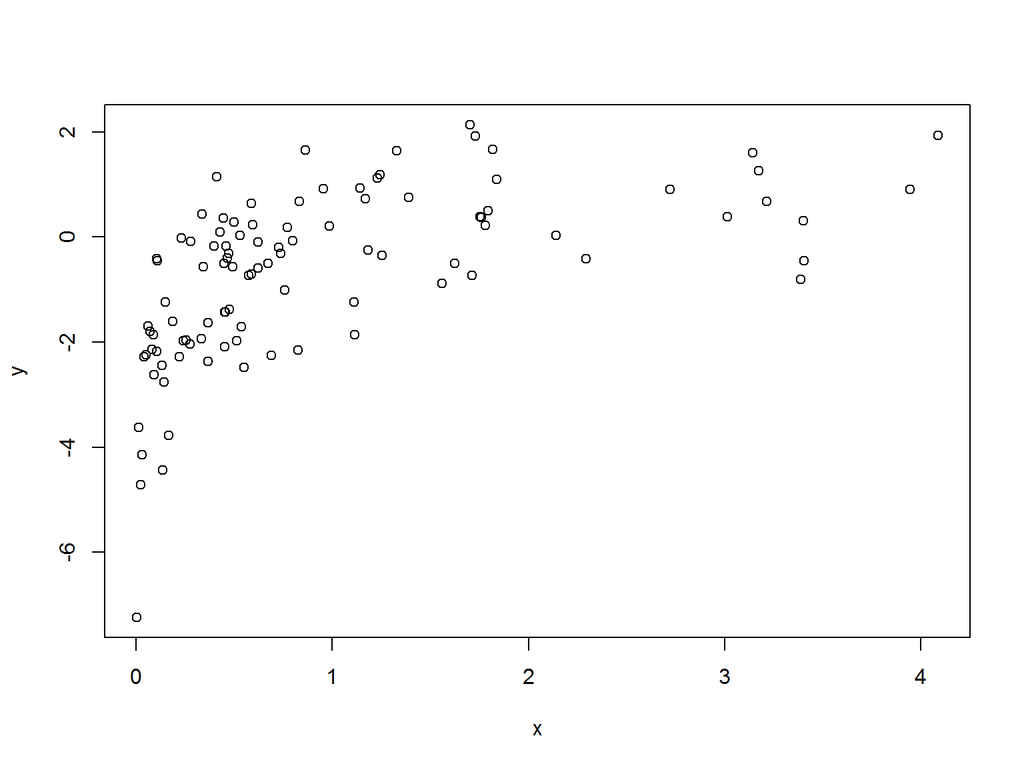

# Smooth fit

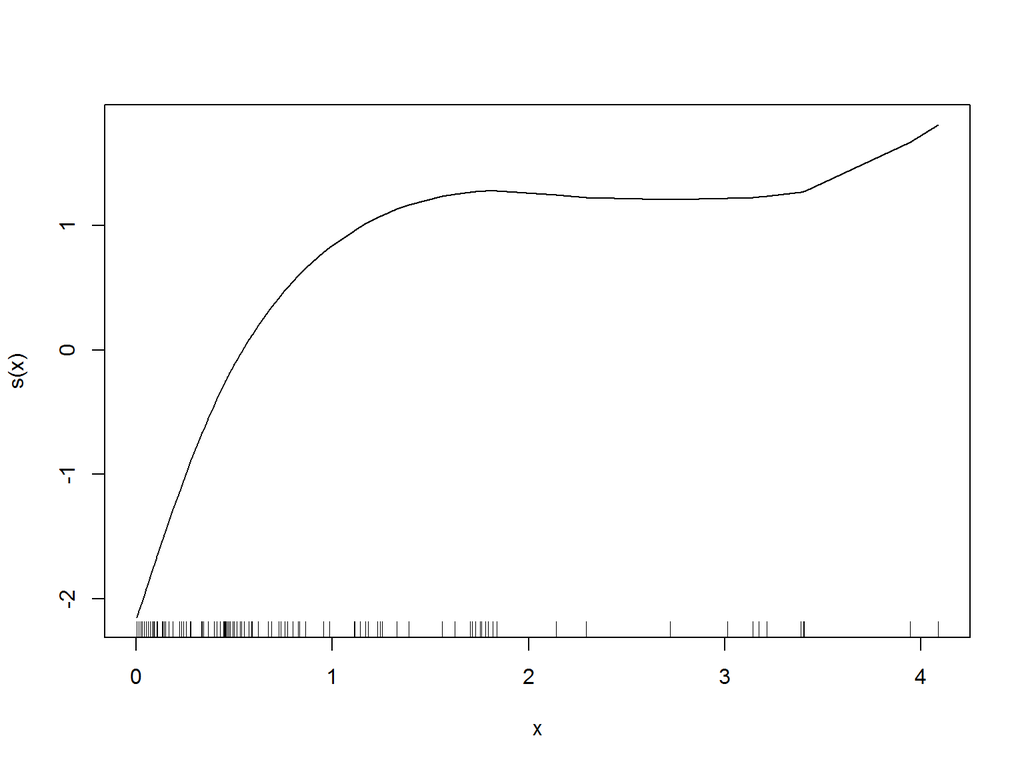

```r
model = gam(y ~ s(x), data=data_set)
plot(model)
```

# Smooth fit

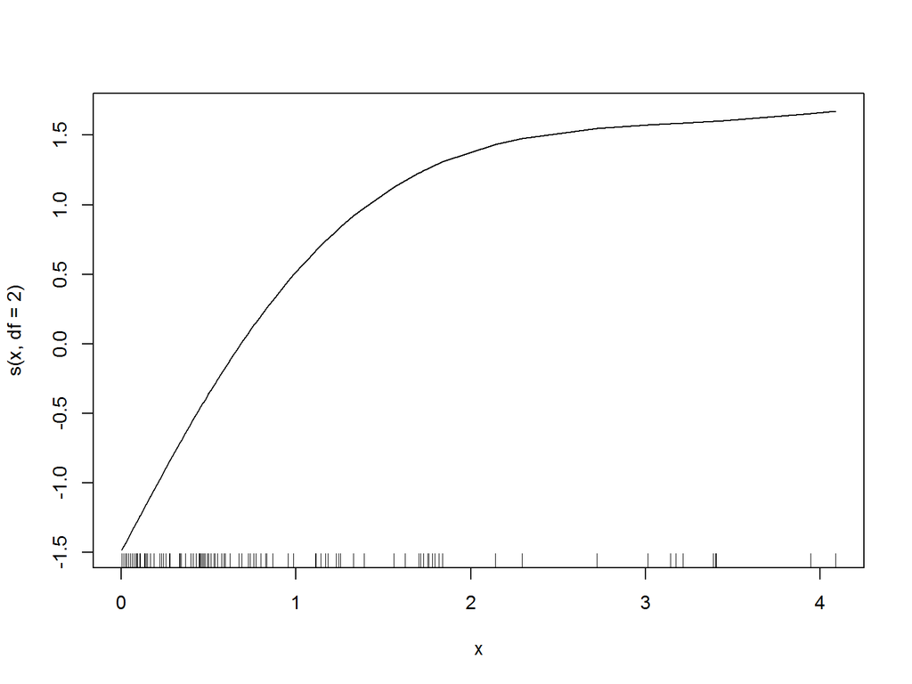

```r
model = gam(y ~ s(x, df=2), data=data_set)
plot(model)
```

# Example

$$y_i = x_i^2 + \epsilon_i$$

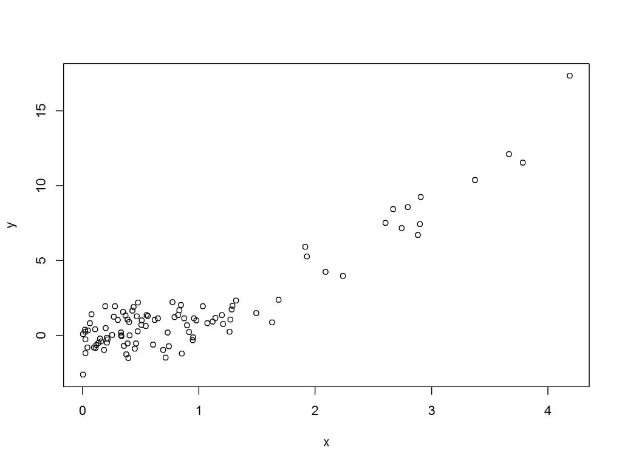

# Smooth fit

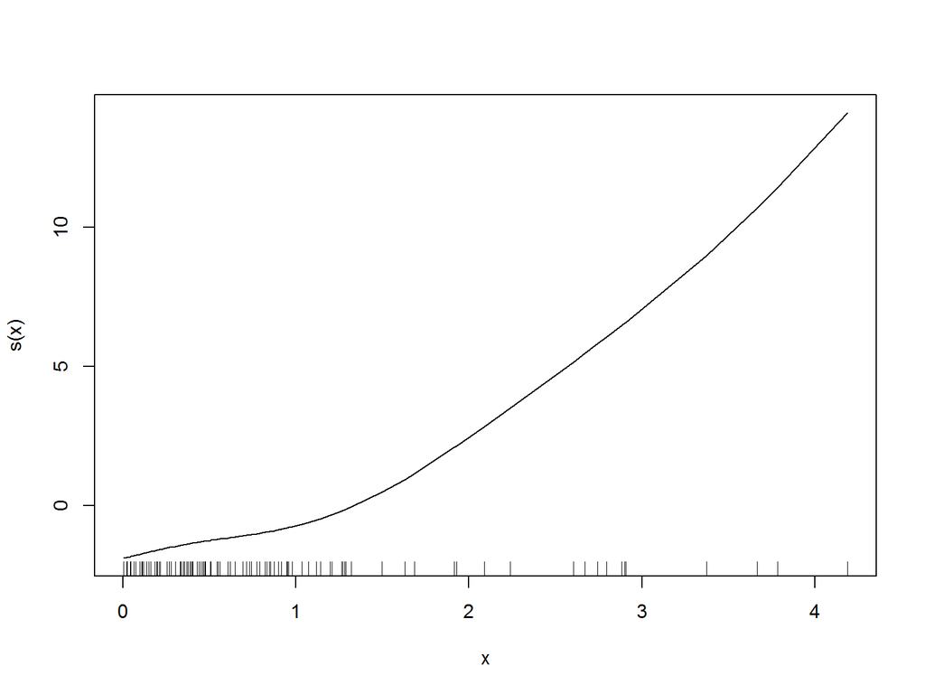

```r
model = gam(y ~ s(x), data=data_set)
plot(model)
```

# Additive logistic regression

For data of the form $\{y_i, x_{i1}, \ldots , x_{ip} \}_{i=1}^{n}$ where $y_i \sim$ Bernoulli($p_i$).

$$\log \left ( \frac{p_i}{1 - p_i} \right ) = s_0 + \sum_{j=1}^{p} s_j(x_{ij})$$

# Additive hazard model

```
##    install_num term payment amount x default prepay
## 1            1    5     300   1000 9       1      0
## 2            1   15     200   2000 6       0      0
## 3            2   15     200   2000 6       0      0
## 4            3   15     200   2000 6       0      1
## 5            1    3     200    500 6       0      0
## 6            2    3     200    500 6       1      0
## 7            1    4     300   1500 5       0      0
## 8            2    4     300   1500 5       0      0
## 9            3    4     300   1500 5       0      0
## 10           4    4     300   1500 5       0      0
```

```r
default_model = gam(default ~ s(install_num) + s(x),
                    data=df,
                    family='binomial')

prepay_model = gam(prepay ~ s(install_num) + s(x),
                   data=df,
                   family='binomial')
```

# Survival functions

```r
score_function = function(x, loan_term, default_model, prepay_model) {
    # initialize data frame to be scored
    x = data.frame(x)
    x = x[rep(1, loan_term),]
    x$install_num = 1:loan_term
    rownames(x) = NULL

    # calculate complement of hazard function by installment
    def_scr = predict(default_model, newdata=x)
    prepay_scr = predict(prepay_model, newdata=x)
    def_scr = 1 / (exp(def_scr) + 1)
    prepay_scr = 1 / (exp(prepay_scr) + 1)

    # calculate default and prepayment curves
    surv_func = data.frame(default_curve = cumprod(def_scr),
                           prepay_curve = cumprod(prepay_scr))

    return(surv_func)
}
```

# Amortization schedule

We also need to know the remaining principal at each installment and so have to compute a loan’s amortization schedule. For this we have to determine the (implicit) interest rate of the loan.

For a loan with loan amount $A$, payment amount $c$ and loan term $n$, the interest rate $r$ is the solution to the equation

$$\frac{A}{\sum_{i=1}^{n} (1 + r)^{-i}} - c = 0 .$$

# Interest calculation

```r
library(nleqslv)

get_interest = function(loan_term, loan_amount, payment_amount) {
    nleqslv(x=1,
            fn=function(x) {
                loan_amount / sum((1 + x)^(-(1:loan_term))) - payment_amount
                })$x
}
```

# Amortization schedule

```r
amortize = function(loan_term, loan_amount, payment_amount) {
    # initialize amortization schedule data frame and calculate interest
    schedule = data.frame(payment = rep(payment_amount, loan_term),
                          principal_payment = rep(0, loan_term),
                          interest_payment = rep(0, loan_term),
                          remaining_principal = rep(0, loan_term))
    rate = get_interest(loan_term, loan_amount, payment_amount)
    interest = loan_amount * rate

    # iteratively populate and return schedule
    schedule[1, 'interest_payment'] = interest
    schedule[1, 'principal_payment'] = payment_amount - interest
    schedule[1, 'remaining_principal'] = loan_amount - schedule[1, 'principal_payment']

    for (i in 2:loan_term) {
        schedule[i, 'interest_payment'] =  schedule[i - 1, 'remaining_principal'] * rate
        schedule[i, 'principal_payment'] =  payment_amount - schedule[i, 'interest_payment']
        schedule[i, 'remaining_principal'] =  schedule[i - 1, 'remaining_principal'] -
            schedule[i, 'principal_payment']
    }
    return(schedule)
}
```

# Amortization schedule

```r
amortize(10, 1000, 120)
```

```
##    payment principal_payment interest_payment remaining_principal
## 1      120          85.39846        34.601538        9.146015e+02
## 2      120          88.35338        31.646620        8.262482e+02
## 3      120          91.41054        28.589457        7.348376e+02
## 4      120          94.57349        25.426512        6.402641e+02
## 5      120          97.84588        22.154124        5.424183e+02
## 6      120         101.23149        18.768506        4.411868e+02
## 7      120         104.73426        15.265740        3.364525e+02
## 8      120         108.35823        11.641774        2.280943e+02
## 9      120         112.10759         7.892413        1.159867e+02
## 10     120         115.98668         4.013318        7.404091e-08
```

# Putting it all together

```r
compute_cash_flow(x,
                  loan_term,
                  loan_amount,
                  payment_amount,
                  default_model,
                  prepay_model,
                  j=0)
```

This returns a list that contains the amortization schedule, estimated default and prepayment curves, expected cash flow by installment, as well as the total expected cash. The extra parameter `j` allows for making updated projections.

# Updating the projections

Given that a loan is current at time $j$ then for $i > j$

$$\text{E}(Y_i) = c \frac{P(T_d > i)}{P(T_d > j)} \frac{P(T_p > i)}{P(T_p > j)} + c_i \frac{P(T_d > i)}{P(T_d > j)} \frac{P(T_p = i)}{P(T_p > j)} .$$

The additional cash expected can be found by summing over $i \in \{j+1, \ldots, n \}$.

# References

- Hastie, T., Tibshirani, R. “Generalized Additive Models.” *Statistical Science*. Vol. 1, No. 3, 1986, pg. 297-318.
- Allison, P. “Discrete-Time Methods for the Analysis of Event Histories.” *Sociological Methodology*. Vol. 13, 1982, pg. 61-98.